# Little Dive Into Sales Data

Lukman

2024-06-28

## Introduction

This project is about deriving insights from a particular sales data. The dataset used was collected from a website and it is meant for practice use only. The data has been cleaned in an excel spreadsheet, so all we just need to do is to carry out some data manipulation, analysis and visualization so as to get insights from the data. So lets dive in!

## Resources Set-Up

### Install and Load Required Packages

This analysis requires the use of popular R package, tidyverse. The code below should help load the tidyverse package.

```r
library(tidyverse)
```

### Loading The Dataset

We can load the dataset using the read.csv function.

```r
sales <- read.csv("C:/Users/U/Desktop/DDP/sales.csv")
```

### About The Dataset

Let’s use the summary function to get a summary about the data.

```r
summary(sales)
```

```
##    Segment            Shipmode           Order.ID             Sales
##  Length:823         Length:823         Length:823         Min.   :    1.167
##  Class :character   Class :character   Class :character   1st Qu.:   34.541
##  Mode  :character   Mode  :character   Mode  :character   Median :  159.975
##                                                           Mean   :  476.547
##                                                           3rd Qu.:  536.110
##                                                           Max.   :23661.228
##                                                           NA's   :1
```

We can also use the head function to give us a brief view of the dataset.

```r
head(sales)
```

```
##    Segment    Shipmode       Order.ID   Sales
## 1 Consumer First Class CA-2011-103366 149.950
## 2 Consumer First Class CA-2011-109043 243.600
## 3 Consumer First Class CA-2011-113166   9.568
## 4 Consumer First Class CA-2011-124023   8.960
## 5 Consumer First Class CA-2011-130155  34.200
## 6 Consumer First Class CA-2011-136861  31.984
```

Now that we know the data we are working with, let’s do some data manipulation to aid our analysis.

## Data Manipulation

We have the sales amount for each respective order in different shipmodes and segments. Let’s assume we have been told that cost of production for each order is half of the sales amount, then we can get the cost using the code below and add it as a new column in our dataset.

```r
sales <- mutate(sales, Cost = Sales/2)
```

Let’s get the profit by substracting the cost from the sales amount and add it as a new column.

```r
sales <- mutate(sales, Profit = Sales - Cost)
```

Take a look at the changes we made

```r
head(sales)
```

```
##    Segment    Shipmode       Order.ID   Sales    Cost  Profit
## 1 Consumer First Class CA-2011-103366 149.950  74.975  74.975
## 2 Consumer First Class CA-2011-109043 243.600 121.800 121.800
## 3 Consumer First Class CA-2011-113166   9.568   4.784   4.784
## 4 Consumer First Class CA-2011-124023   8.960   4.480   4.480
## 5 Consumer First Class CA-2011-130155  34.200  17.100  17.100
## 6 Consumer First Class CA-2011-136861  31.984  15.992  15.992
```

## Getting Into Data Analysis

Firstly, let’s know our profit by ship mode.

```r
profit_by_shipmode <- sales %>% drop_na() %>% group_by(Shipmode) %>% summarize(total_profit = sum(Profit, na.rm = TRUE)) %>% arrange(-total_profit)
profit_by_shipmode
```

```
## # A tibble: 4 × 2
##   Shipmode       total_profit
##   <chr>                 <dbl>
## 1 Standard Class      113807.
## 2 Second Class         46879.
## 3 First Class          24666.
## 4 Same Day             10509.
```

Standard class made the largest profit.

Then our profit by segment

```r
profit_by_segment <- sales %>% drop_na() %>% group_by(Segment) %>% summarize(total_profit = sum(Profit, na.rm = TRUE)) %>% arrange(-total_profit)
profit_by_segment
```

```
## # A tibble: 3 × 2
##   Segment     total_profit
##   <chr>              <dbl>
## 1 Consumer          97790.
## 2 Corporate         60943.
## 3 Home Office       37128.
```

The largest portion of profit was obtained from the consumer segment.

It will also be useful to know number of orders from each segment.

```r
order_by_segment <- sales %>% drop_na() %>% group_by(Segment) %>% summarize(total_orders = n()) %>% arrange(-total_orders)
order_by_segment
```

```
## # A tibble: 3 × 2
##   Segment     total_orders
##   <chr>              <int>
## 1 Consumer             444
## 2 Corporate            247
## 3 Home Office          131
```

Fair enough, consumer segment has the most orders since it has the largest profit also.

Then the number of orders by different ship modes

```r
order_by_shipmode <- sales %>% drop_na() %>% group_by(Shipmode) %>% summarize(total_orders = n()) %>% arrange(-total_orders)
order_by_shipmode
```

```
## # A tibble: 4 × 2
##   Shipmode       total_orders
##   <chr>                 <int>
## 1 Standard Class          495
## 2 Second Class            164
## 3 First Class             124
## 4 Same Day                 39
```

Standard class has the most orders.

That should be okay for analysis. Let’s get to the real deal.

## Data Visualization

What about we visualize the profit made by different segment using a column chart, which is suitable for making comparism

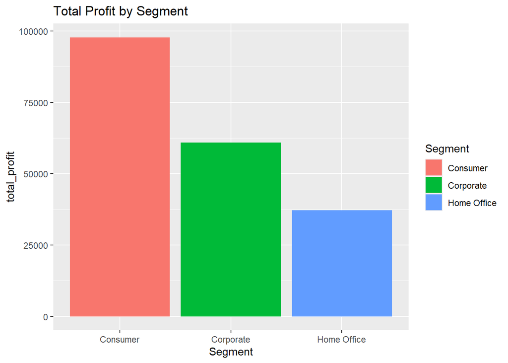

```r
ggplot(profit_by_segment) +
  geom_col(mapping = aes(x= Segment, y = total_profit, fill = Segment)) +
  labs(title = "Total Profit by Segment")
```

Nice!

Lets do the same to the profit made on different shipmodes

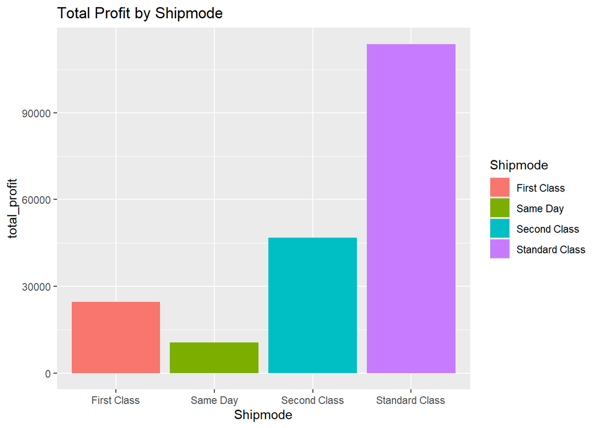

```r
ggplot(profit_by_shipmode) +
  geom_col(mapping = aes(x = Shipmode, y = total_profit, fill = Shipmode)) +
  labs(title = "Total Profit by Shipmode")
```

Now let’s do something different.We will be using a pie chart to help us draw more insights on the number of orders in different segment. We’ll need to add a percentage column for better clarity before drawing the pie chart.

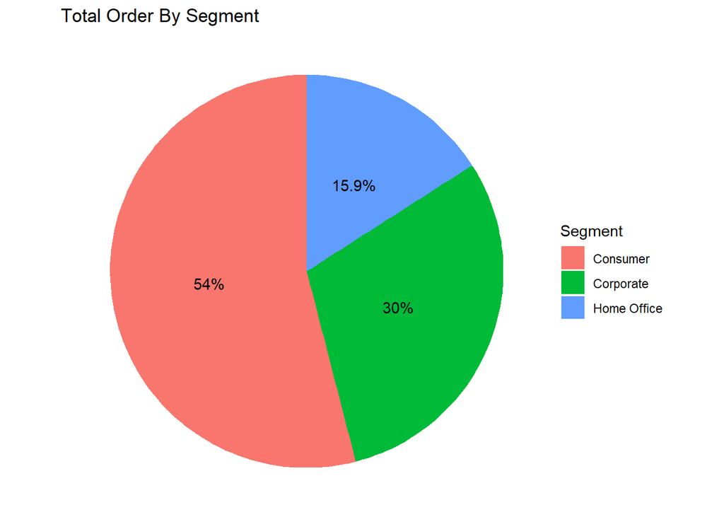

```r
order_by_segment$percentage <- round(order_by_segment$total_orders /sum(order_by_segment$total_orders) * 100, 1)
ggplot(order_by_segment, aes(x="", y = total_orders, fill = Segment)) +
  geom_bar(width = 1, stat = "identity") +
  coord_polar(theta = "y") +
  labs(title = "Total Order By Segment") +
  theme_void() +
  geom_text(aes(label = paste0(percentage, "%")),position = position_stack(vjust = 0.5))
```

Let’s use the same idea to visualize the number of orders by different ship mode.

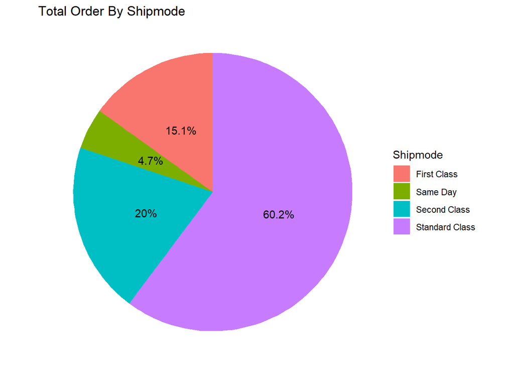

```r
order_by_shipmode$percentage <- round(order_by_shipmode$total_orders /sum(order_by_shipmode$total_orders) * 100, 1)
ggplot(order_by_shipmode, aes(x="", y = total_orders, fill = Shipmode)) +
  geom_bar(width = 1, stat = "identity") +
  coord_polar(theta = "y") +
  labs(title = "Total Order By Shipmode") +
  theme_void() +
  geom_text(aes(label = paste0(percentage, "%")),position = position_stack(vjust = 0.5))
```

Cool!

## Insights

- The most profit was made by the consumer segment, followed by the corporate segment, which means the home office segment made the least profit.
- Based on ship mode, the standard class and second class made the most profit.
- The consumer segment had more than half of the total orders.
- Standard class also obtained more than half of the total orders, based on ship mode.

**Not bad!**